# Reproducible Research - Peer Assessment 1

#### Loading and Preprocessing the Data

##### Load the Data

```r
setwd("~/RWD/RepDataPA1")
actdata <- read.csv("activity.csv", colClasses = c("numeric", "character", "numeric"))
head(actdata)
```

```
##   steps       date interval
## 1    NA 2012-10-01        0
## 2    NA 2012-10-01        5
## 3    NA 2012-10-01       10
## 4    NA 2012-10-01       15
## 5    NA 2012-10-01       20
## 6    NA 2012-10-01       25
```

##### Process/Transform the data

```r
names(actdata)
```

```
## [1] "steps"    "date"     "interval"
```

```r
library(lattice)
```

```r
actdata$date <- as.Date(actdata$date, "%Y-%m-%d")
```

#### What is Mean Total Number of Steps Per Day?

##### Calculate the total number of steps taken per day

```r
TotalSteps <- aggregate(steps ~ date, data = actdata, sum, na.rm = TRUE)
```

##### Plot a histogram of the total number of steps taken each day

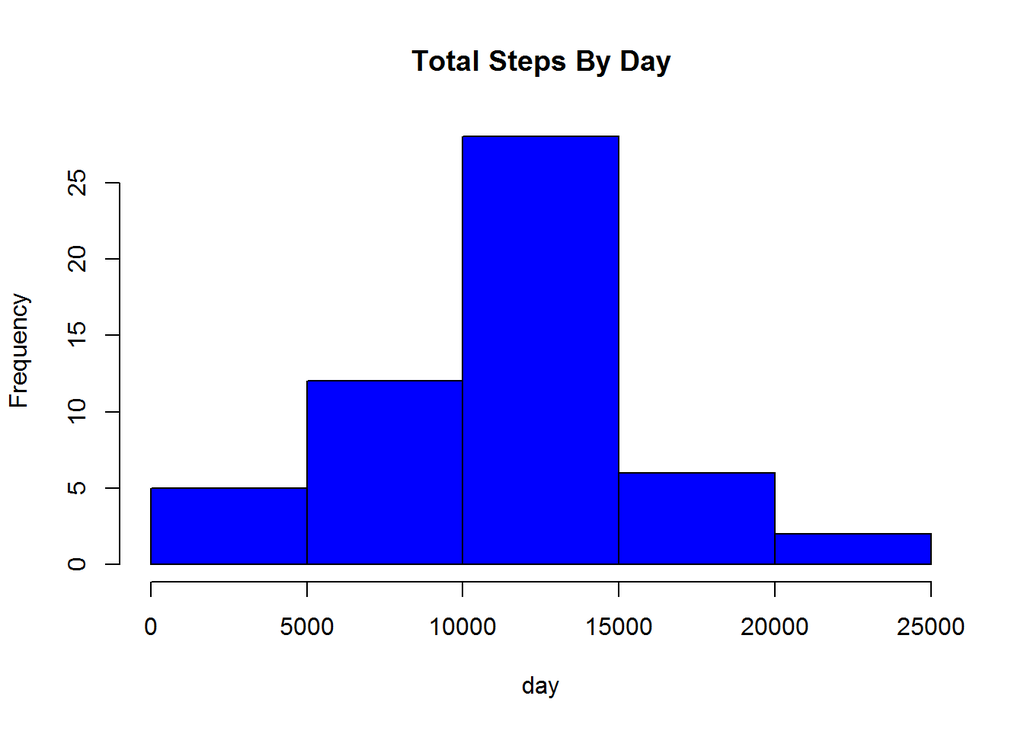

```r
hist(TotalSteps$steps, main = "Total Steps By Day", xlab = "day", col = "blue")
```

##### Calculate and report the mean and median of the total number of steps taken per day

```r
mean(TotalSteps$steps)
```

```
## [1] 10766.19
```

```r
median(TotalSteps$steps)
```

```
## [1] 10765
```

#### What is The Average Daily Activity Pattern?

##### Make a time series plot of the 5-minute interval and the average number of steps taken, averaged across all days

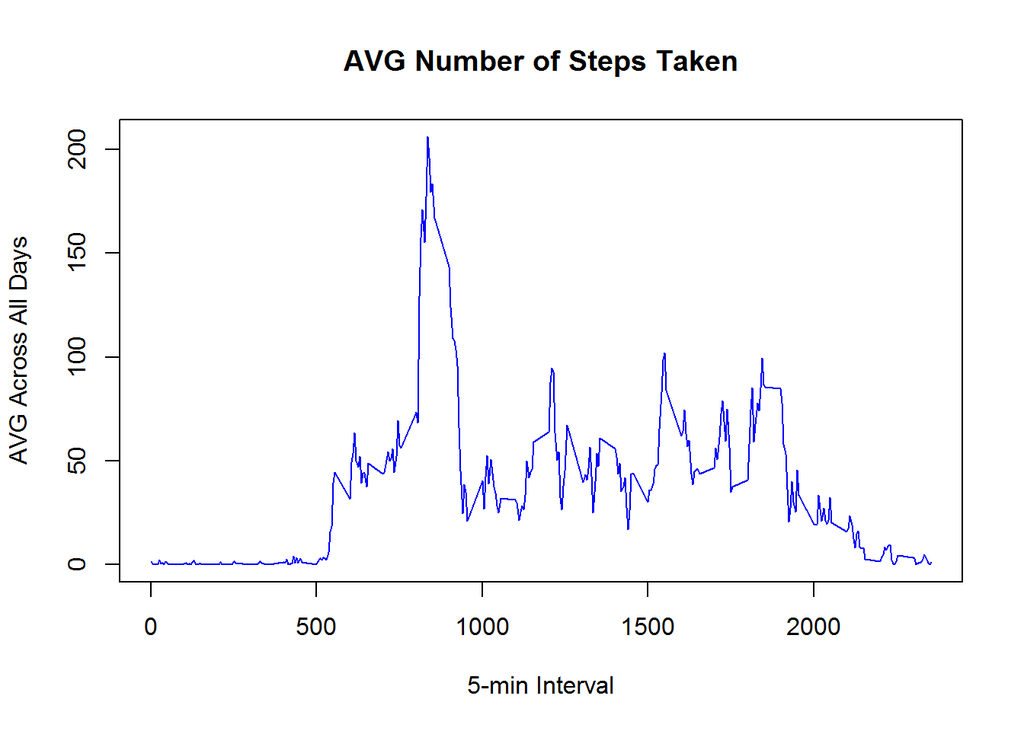

```r
time_series <- tapply(actdata$steps, actdata$interval, mean, na.rm = TRUE)
plot(row.names(time_series), time_series, type = "l", xlab = "5-min Interval",
     ylab = "AVG Across All Days", main = "AVG Number of Steps Taken",
     col = "blue")
```

##### Which 5-minute interval, on average across all of the days in the dataset, contains the maximum number of steps?

```r
IntervalMax <- which.max(time_series)
names(IntervalMax)
```

```
## [1] "835"
```

#### Imputing Missing Values

##### Calculate and report the total number of missing values in the dataset

```r
activity_NA <- sum(is.na(actdata))
activity_NA
```

```
## [1] 2304
```

##### Devise a strategy for filling in all of the missing values in the dataset

```r
AvgSteps <- aggregate(steps ~ interval, data = actdata, FUN = mean)
NAData <- numeric()
for (i in 1:nrow(actdata)) {
        obs <- actdata[i, ]
        if (is.na(obs$steps)) {
                steps <- subset(AvgSteps, interval == obs$interval)$steps
        } else {
                steps <- obs$steps
        }
        NAData <- c(NAData, steps)
}
```

##### Create a new dataset that is equal to the original dataset but with the missing data filled in

```r
new_actdata <- actdata
new_actdata$steps <- NAData
```

##### Make a histogram of the total number of steps taken each day and calculate and report the mean and median total number of steps taken per day.

###### Histogram

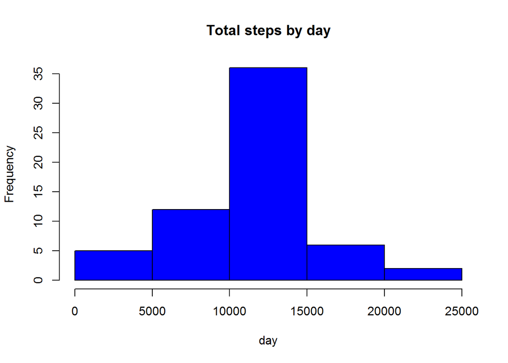

```r
TotalSteps2 <- aggregate(steps ~ date, data = new_actdata, sum, na.rm = TRUE)
hist(TotalSteps2$steps, main = "Total steps by day", xlab = "day", col = "blue")
```

###### Mean & Median:

```r
mean(TotalSteps2$steps)
```

```
## [1] 10766.19
```

```r
median(TotalSteps2$steps)
```

```
## [1] 10766.19
```

###### Results Analysis

The Mean has stayed the same but the Median has altered slightly.

#### Are There Differences In Activity Patterns Between Weekdays And Weekends?

##### Create a new factor variable in the dataset with two levels - “weekday” and “weekend” indicating whether a given date is a weekday or weekend day.

```r
day <- weekdays(actdata$date)
daylevel <- vector()
for (i in 1:nrow(actdata)) {
        if (day[i] == "Saturday") {
                daylevel[i] <- "Weekend"
        } else if (day[i] == "Sunday") {
                daylevel[i] <- "Weekend"
        } else {
                daylevel[i] <- "Weekday"
        }
}
actdata$daylevel <- daylevel
actdata$daylevel <- factor(actdata$daylevel)

StepsByDay <- aggregate(steps ~ interval + daylevel, data = actdata, mean)
names(StepsByDay) <- c("interval", "daylevel", "steps")
```

##### Make a panel plot containing a time series plot of the 5-minute interval and the average number of steps taken, averaged across all weekday days or weekend days.

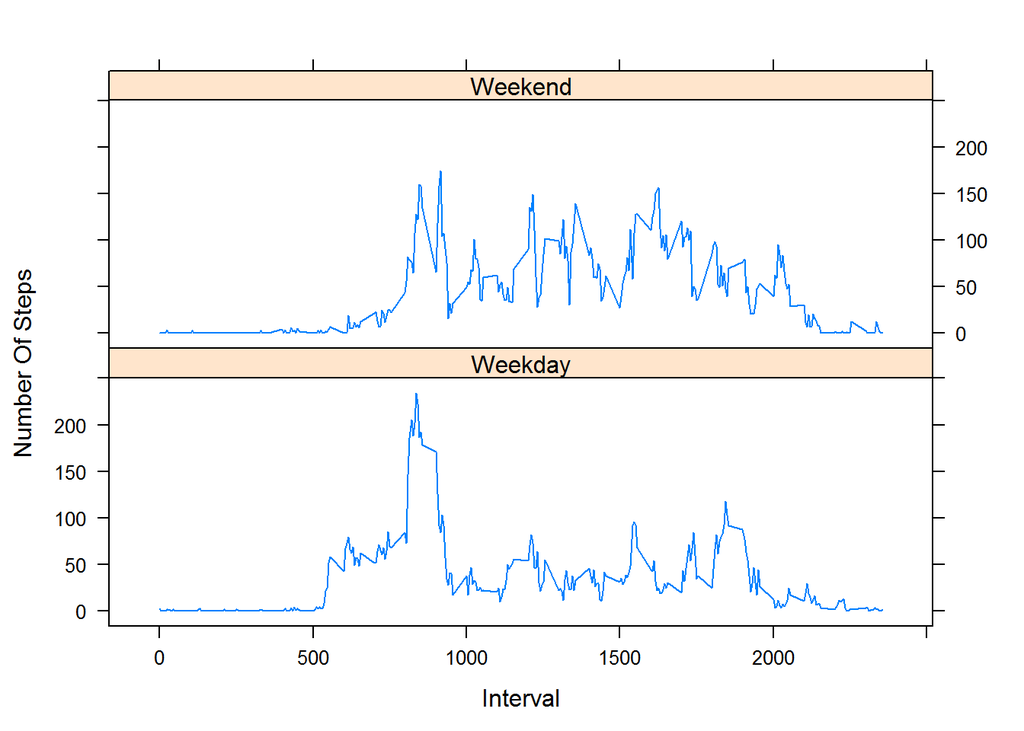

```r
xyplot(steps ~ interval | daylevel, StepsByDay, type = "l", layout = c(1, 2),
       xlab = "Interval", ylab = "Number Of Steps")
```